# Estimadores de Máxima Verossimilhança para Assimetria e Curtose usando a expansão de Gram-Charlier

Wilson Freitas

18 de abril de 2018

## Introdução

Qualquer função de densidade de probabilidade (FDP) pode ser aproximada por uma expansão em série de outra FDP que pertence a um grupo especial, como a distribuição Gaussiana, por exemplo. Dada uma amostra, é difícil identificar a melhor distribuição para descrevê-la, logo, a utilização expansões em séries permite associar uma FDP aproximada aos dados. A FDP aproximada é uma expansão em série de uma distribuição conhecida e em geral padronizada, esta é a distribuição base. Esta aproximação permite lidar com momentos que não estão presentes na distribuição base. Por exemplo, a distribuição Gaussiana não possui os momentos de assimetria e curtose, entretanto, na expansão em série da Gaussiana estes momentos são parâmetros. Portanto, se os dados apresentam assimetria e curtose, a distribuição Gaussiana não é uma candidata, contudo, a sua expansão é. As expansões de FDPs em séries têm aplicações em diversos campos da ciência como a Física e Finanças. Este texto explora o uso da expansão de Gram-Charlier [1] que é a expansão da distribuição Gaussiana em uma base de polinônmios de Hermite.

## Assimetria e curtose

Seja uma variável aleatória $x$, de média amostral $\mu$ e variância amostral $\sigma^2$. Os estimadores amostrais de assimetria $\mu_3$ e curtose $\mu_4$ são definidos como:

$$\mu_3 = \frac{1}{N} \sum_{i=1}^{N} \frac{(x_i - \mu)^3}{\sigma^3}$$

e

$$\mu_4 = \frac{1}{N} \sum_{i=1}^{N} \frac{(x_i - \mu)^4}{\sigma^4}$$

```r
load("../BVSP.RData")
IBOV = rbcb::get_series(c(IBOVESPA = 7), start_date = "1997-04-01", end_date = "2017-04-01") %>% filter(!is.na(IBOVESPA))
rIBOV = data.frame(
  date = IBOV$date[-1],
  value = diff(log(IBOV$IBOVESPA))
)
```

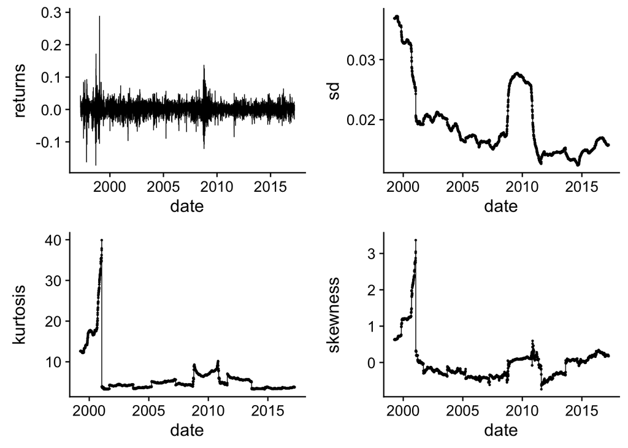

```r
p1 = qplot(date, value, data = rIBOV, geom="line", ylab = "returns", size = I(0.3))
r1 = zoo::rollapply(rIBOV$value, width = 504, sd)
p2 = qplot(tail(rIBOV$date, length(r1)), r1, geom=c("line", "point"), xlab = "date", ylab = "sd", size = I(0.3))
r2 = zoo::rollapply(rIBOV$value, width = 504, timeDate::kurtosis, method = "moment")
p3 = qplot(tail(rIBOV$date, length(r2)), r2, geom=c("line", "point"), xlab = "date", ylab = "kurtosis", size = I(0.3))
r3 = zoo::rollapply(rIBOV$value, width = 504, timeDate::skewness, method = "moment")
p4 = qplot(tail(rIBOV$date, length(r3)), r3, geom=c("line", "point"), xlab = "date", ylab = "skewness", size = I(0.3))

plot_grid(p1, p2, p3, p4, align = "v")
```

Como é possível observar na figura acima, nos gráficos de média móvel de assimetria e curtose, há em diversos momentos mudanças de nível significativas, relacionadas a períodos de maior volatilidade nos retornos. O gráfico com a média móvel do desvio padrão, por sua vez, apresnta uma comportamento mais suave, nos mesmos períodos. Além das grandes variações, estes estimadores apresentam valores extremos que de certa forma são pouco plausíveis.

## Expansão de Gram-Charlier

Sob certas condições uma FDP $p(x)$, padronizada, pode ser expandida em uma série de derivadas de

$$Z(x) = \frac{1}{\sqrt{2\pi}}\exp\left(-\frac{x^2}{2}\right)$$

que é a FDP Gaussinana padronizada. A expansão em série

$$p(x) \sim \sum_{n=0}^\infty c_n \frac{d^n Z(x)}{dx^n}$$

é uma série de Gram-Charlier (de tipo-A) e de acordo com a fórmula de Rodriguez

$$He_n(x) = (-1)^n \exp\left( \frac{x^2}{2} \right) \frac{d^n}{dx^n} \exp\left( -\frac{x^2}{2} \right)$$

onde $He_n(x)$ são polinômios de Chebyshev-Hermite de ordem $n$, temos que:

$$p(x) \sim \sum_{n=0}^\infty c_n (-1)^n He_n(x) Z(x)$$

e coeficientes $c_n$ são dados por:

$$c_n = \frac{(-1)^n}{n!} \int_{-\infty}^{\infty} p(t) He_n(t) dt$$

que são como valores esperados dos polinômios de Chebyshev-Hermite com relação a FDP $p(x)$ que desejamos expandir na série de polinômios. Calculando valores esperados de polinômios para encontrar os coeficientes $c_n$ é natural que surjam momentos da distribuição $p(x)$, de maneira que a expansão de Gram-Charlier também seja uma expansão em momentos da distribuição.

Considerando uma descrição parsimoniosa e a dificuldade em trabalhar com séries infinitas, é razoável truncar a série em uma quantidade de termos de ordem $n$ finita, e uma boa escolha é $n=4$. Esta escolha produz a seguinte aproximação para a FDP $p(x)$

$$p(x) \sim Z(x)\left[ 1 + \frac{\mu_3}{3!} (x^3 - 3x) + \frac{\mu_4 - 3}{4!} (x^4 - 6x^2 + 3) \right]$$

onde, além da distribuição Gaussiana $Z(x)$, tem-se os terceiro e quarto momentos, $\mu_3 = E[x^3]$ e $\mu_4 = E[x^4]$ da variável aleatória $x$ padronizada e portanto estes momentos centralizados são assimetria e curtose, respectivamente. O truncamento da expansão de Gram-Charlier em termos até a ordem $n=4$ produz uma FDP paramétrica em assimetria e curtose o que permite descrever variáveis aleatórias que apresentem eventos extremos (oscilações distantes da média) e assimetria. Variáveis com estes comportamentos são de interesse em problemas de finanças, para o cálculo de risco, geração de cenários e apreçamento de derivativos.

Na próxima seção mostraremos como obter os estimadores de máxima-verossimilhança de assimetria e curtose na distribuição de Gram-Charlier obedecendo a restrição de positividade da função de densidade de probabilidade.

## Estimadores para assimetria e curtose na distribuição de Gram-Charlier

A assimetria e curtose serão estimados a partir da distribuição paramétrica de Gram-Charlier via máxima-verossimilhança (MV).

$$p(x; \mu_3, \mu_4) = Z(x)\left[ 1 + \frac{\mu_3}{3!} (x^3 - 3x) + \frac{\mu_4 - 3}{4!} (x^4 - 6x^2 + 3) \right]$$

Esta distribuição apresenta valores negativos de $p(x)$ para alguns valores de assimetria e curtose e vamos observar isso através da função de log-verossimilhança $l(\mu_3, \mu_4; \mathbf{x})$ construída a partir dessa distribuição.

$$l(\mu_3, \mu_4; \mathbf{x}) = \sum_{i=1}^N \log p(x_i; \mu_3, \mu_4)$$

como a função $\log$ possui apenas suporte positivo, valores negativos de $p(x)$ apresentarão erros quando calculados numericamente e dessa forma será possível separar os pontos com erros dos demais.

Abaixo definimos a função de densidade de probabilidade de Gram-Charlier $p(x)$ como a função `dgramcharlier` e sua função de MV `gclogLik`.

```r
dgramcharlier <- function(x, mu3=0, mu4=3) {
  psi <- function(x) ( 1 + mu3*(x^3 - 3*x)/6 + (mu4 - 3)*(x^4 - 6*x^2 + 3)/24 )
  dnorm(x)*psi(x)
}

gclogLik <- function(x) {
  function(parms) {
    gc <- dgramcharlier(x, mu3=parms[1], mu4=parms[2])
    -sum(log(gc))
  }
}
```

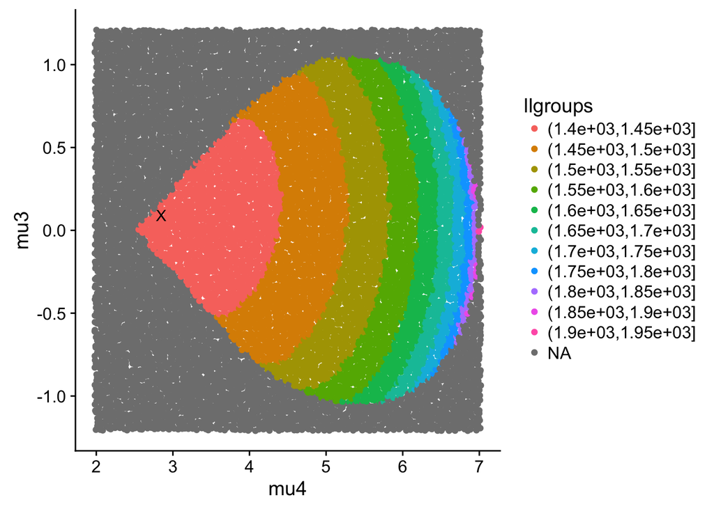

```r
set.seed(0)
y <- rnorm(1000)
comb <- expand.grid(mu3=seq(-1.2, 1.2, length.out = 100),
                    mu4=seq(2, 7, length.out = 100))

logLik <- gclogLik(y)
z <- sapply(seq_len(dim(comb)[1]), function(i) {
  parms <- as.numeric(comb[i,])
  logLik(parms)
})

comb$ll <- z
h <- hist(z, 10, plot = FALSE)
comb$llgroups <- cut(z, h$breaks)

ggplot(comb, aes(x=mu4, y=mu3, colour=llgroups)) +
  geom_jitter() +
  annotate('text', label='X',
           y=timeDate::skewness(y), x=timeDate::kurtosis(y, method='moment'))
```

```r
bove <- x
```

Agora vamos construir um *grid* para as variáveis $\mu_3$ e $\mu_4$, aplicar a função de verissimilhança a amostra e aplicá-la aos parâmetros do *grid*.

```r
comb <- expand.grid(mu3=seq(-1.2, 1.2, length.out = 100),
                    mu4=seq(3, 17, length.out = 100))

logLik <- gclogLik(x)
z <- sapply(seq_len(dim(comb)[1]), function(i) {
  parms <- as.numeric(comb[i,])
  logLik(parms)
})

comb$ll <- z
h <- hist(z, 10, plot = FALSE)
comb$llgroups <- cut(z, h$breaks)
```

Agora podemos observar a função de verossimilhança dos retornos do IBOVESPA no espaço paramétrico.

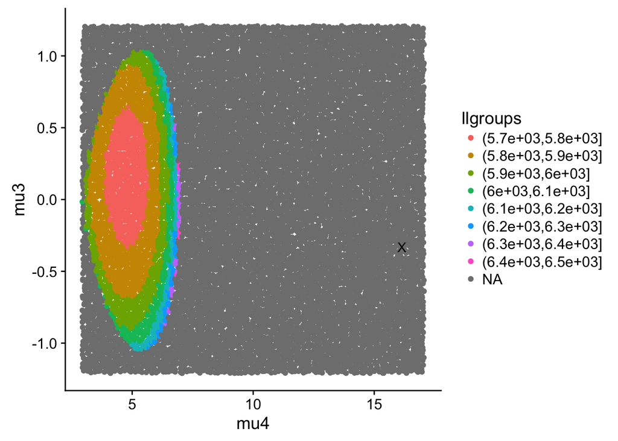

```r
ggplot(comb, aes(x=mu4, y=mu3, colour=llgroups)) +
  geom_jitter() +
  annotate('text', label='X',
           y=timeDate::skewness(x), x=timeDate::kurtosis(x, method='moment'))
```

Para utilizarmos a função de log-verossimilhança em um processo numérico para estimar a assimetria e a curtose, é necessário encontrar uma forma funcional na qual seja possível tratar as restrições de forma analítica e de preferência sem condicionais.

### Encontrando a região de validade

Como pudemos observar nos gráficos temos um plano $(\mu_3, \mu_4)$ onde a região que define o “ovo” nos gráficos acima é a região de validade para os parâmetros $\mu_3$ e $\mu_4$. Portanto, queremos encontar esta região e para isso vamos começar determinando a borda dessa região.

Queremos valores para $\mu_3$ e $\mu_4$ tais que $p(x)$ seja positivo definido para qualquer $x$. Observando a distribuição de Gram-Charlier temos que o seguinte polinômio deve ser sempre positivo para qualquer $x$.

$$f(x) = 1 + \frac{\mu_3}{6} He_3(x) + \frac{(\mu_4 - 3)}{24} He_4(x) \geq 0$$

A borda dessa região é definida por

$$f(x) = 1 + \frac{\mu_3}{6} He_3(x) + \frac{(\mu_4 - 3)}{24} He_4(x) = 0$$

que define uma linha no plano $(\mu_3, \mu_4)$ para cada valor de $x$. Derivando $f(x)$ e igualando a zero temos uma função que é independente de $x$, no sentido que para qualquer valor de $x$ essa derivada é nula.

$$f^\prime(x) = \frac{\mu_3}{3} He_2(x) + \frac{(\mu_4 - 3)}{6} He_3(x) = 0$$

Com isso podemos construir um sistema linear para encontrar $\mu_3$ e $\mu_4$ como funções de $x$, pois na primeira equação definimos a restrição em relação a $x$ e na segunda temos uma restrição mais geral para qualquer valor de $x$. As soluções $\mu_3$ e $\mu_4$ para este sistema determinam a borda do “ovo” observado nos gráficos acima.

A solução do sistema é dada por:

$$\mu_3(x) = -24\frac{He_3(x)}{d(x)}$$

e

$$\mu_4(x) = 72\frac{He_2(x)}{d(x)} + 3$$

Agora é necessário analisar estas equações para determinar as regiões em $x$ para que $\mu_3(x)$ e $\mu_4(x)$ tenham valores válidos. Sabemos que $\mu_3(x) \ge 0$ ou $\mu_3(x) \lt 0$ e que $\mu_4(x) \ge 3$, com base nisso chegamos as seguintes regiões para $x$.

| Restrições | Regiões de $x$ |
| --- | --- |
| $\mu_3 \lt 0$ | $x \gt \sqrt{3} \cup -\sqrt{3} \lt x \lt 0$ |
| $\mu_3 \ge 0$ | $x \le -\sqrt{3} \cup 0 \lt x \lt \sqrt{3}$ |
| $\mu_4 \lt 3$ | $-1 \lt x \lt 1$ |
| $\mu_4 \ge 3$ | $x \ge 1 \cup x \le -1$ |

Tomando a intercecção das restrições válidas chegamos a 2 conjuntos para $x$

- $x \in (-\infty -\sqrt{3}) \cup (\sqrt{3}, \infty)$ (menor)
- $x \in (-\sqrt{3}, \sqrt{3})$ (maior — admite valores inválidos para $\mu_4$)

Note que estes conjuntos definem regiões de $x$ onde o polinômio da equação de Gram-Charlier é igual a zero e consequentemente, os valores de $\mu_3$ e $\mu_4$ são válidos dentro dessa restrição.

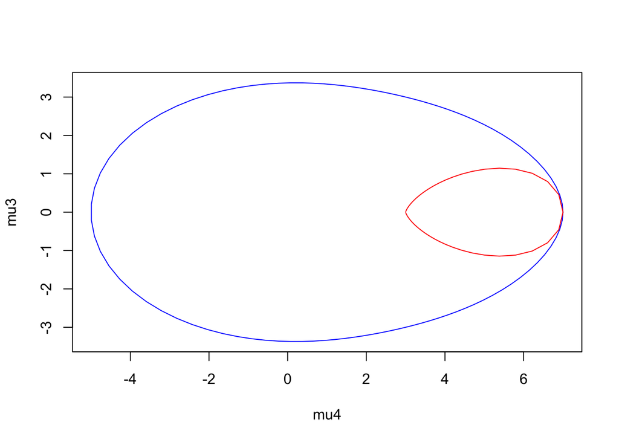

```r
d_poly <- function(x) {
  2*(x^3 - 3*x)^2 - 1*(x^2 - 1)*(x^4 - 6*x^2 + 3)
}

mu3 <- function(x) {
  -12 * (x^3 - 3*x)/d_poly(x)
}

mu4 <-function(x) {
  24 * (x^2 - 1)/d_poly(x) + 3
}

x <- seq(-sqrt(3), sqrt(3), length.out=100)
plot(data=cbind(mu3=mu3(x), mu4=mu4(x)), mu3 ~ mu4, type='l', col='blue')
x <- c(seq(-10, -sqrt(3), length.out=100), seq(sqrt(3), 10, length.out=100))
lines(data=cbind(mu3=mu3(x), mu4=mu4(x)), mu3 ~ mu4, type='l', col='red')
```

### Eliminando as restrições

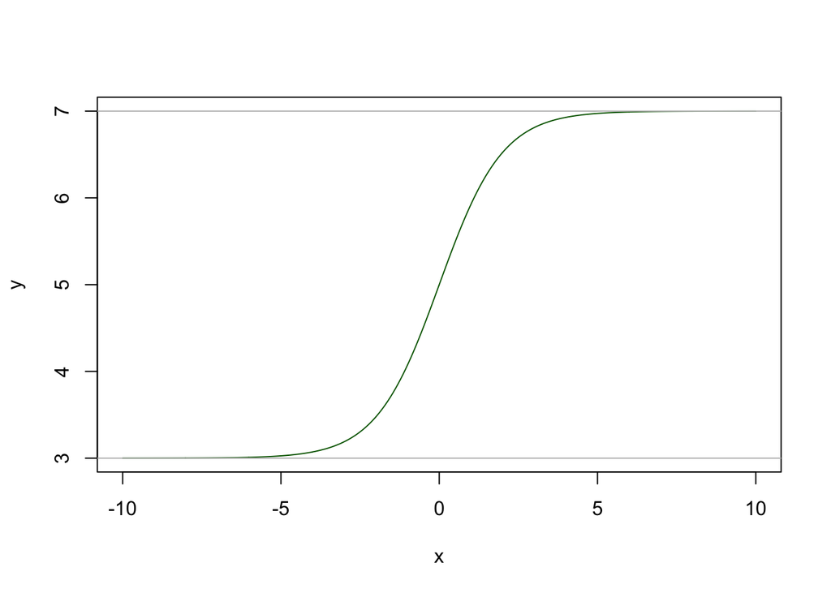

```r
ff <- function(x, a, b) a + (b - a)/(1 + exp(-x))
x_ <- seq(-10, 10, length.out=1000)
df_ <- data.frame(x=x_, y=ff(x_, 3, 7))
plot(y ~ x, data=df_, type="l", col="darkgreen")
abline(h=c(3, 7), col="grey")
```

A partir de $\mu_4^\prime$ encontramos $\mu_4$ e com isso aplicamos a função do *ovo* para encontrar os limites para $\mu_3$ ($\mu_{3,inf}$ e $\mu_{3,sup}$ como função de $\mu_4$) e utilizamos a função $f$ para a partir de $\mu_3^\prime$ encontrar $\mu_3$. Com essa transformação analítica eliminamos o problema de restrição da busca por $\mu_3$ e $\mu_4$ pois o problema passa a ser posto em termos de $\mu_3^\prime$ e $\mu_4^\prime$.

### Otimizando

```r
gcUnconstrainedlogLik <- function(x) {
  function(parms) {
    parms <- uncons_regionD(parms[1], parms[2])
    gc <- dgramcharlier(x, mu3=parms[1], mu4=parms[2])
    gc <- abs(gc)
    -sum(log(gc))
  }
}

d_poly <- function(x) {
  2*(x^3 - 3*x)^2 - 1*(x^2 - 1)*(x^4 - 6*x^2 + 3)
}

mu3 <- function(x) {
  -12 * (x^3 - 3*x)/d_poly(x)
}

mu4 <-function(x) {
  24 * (x^2 - 1)/d_poly(x) + 3
}

regionD <- function(x) {
  dm <- cbind(x=x, mu3=mu3(x), mu4=mu4(x))
  idx <- order(dm[,'mu4'])
  dm[idx,]
}

adj_seq <- function(start, end, a=-3, length.out=100) {
  x <- seq(start^a, end^a, length.out=length.out)
  x^(1/a)
}

create_uncons_regionD <- function() {
  x <- adj_seq(sqrt(3), 100)
  rd <- regionD(x)
  rd_curve <- approxfun(rd[,'mu4'], rd[,'mu3'])
  ff <- function(x, a, b) a + (b - a)/(1 + exp(-x))
  function(mu3p, mu4p) {
    mu4 <- ff(mu4p, 3, 7)
    mu3_l <- rd_curve(mu4)
    mu3_u <- -mu3_l
    mu3 <- ff(mu3p, mu3_l, mu3_u)
    c(mu3, mu4)
  }
}

uncons_regionD <- create_uncons_regionD()
```

Para a amostra aleatória

```r
x <- y
logLik <- gcUnconstrainedlogLik(x)

res <- optim(c(0, 3), logLik, method='BFGS')
```

|  | Assimetria | Curtose |
| --- | --- | --- |
| MLE | 0.0000274 | 3.000017 |
| Amostra | 0.0917250 | 2.847665 |

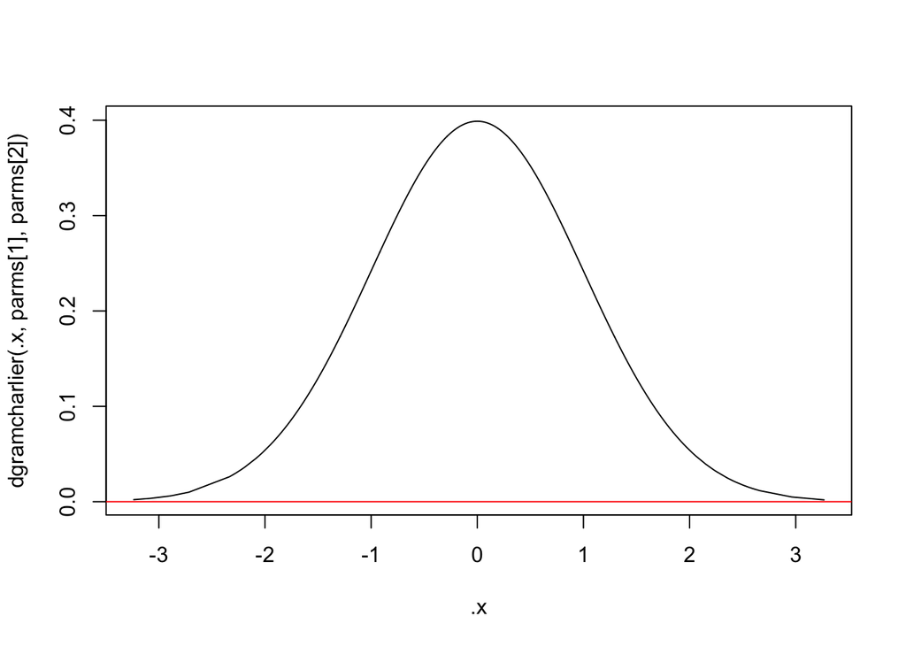

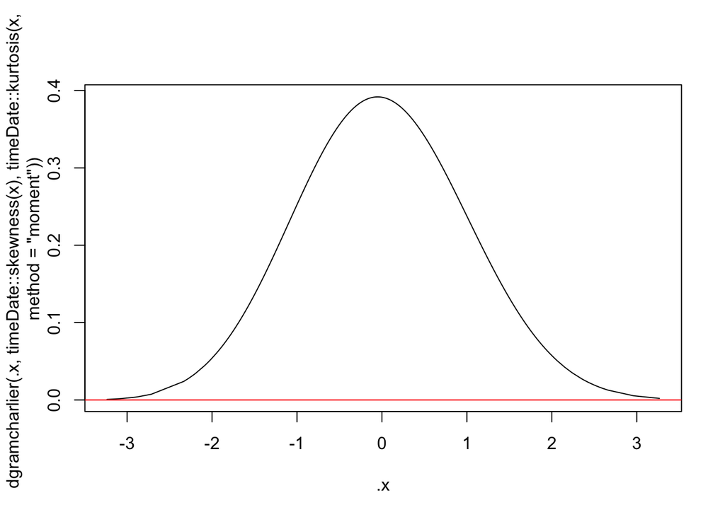

```r
.x <- sort(x)
parms <- uncons_regionD(res$par[1], res$par[2])
plot(.x, dgramcharlier(.x, parms[1], parms[2]), type='l')
abline(h=0, col="red")
plot(.x, dgramcharlier(.x, timeDate::skewness(x), timeDate::kurtosis(x, method='moment')), type='l')
abline(h=0, col="red")
```

Para o IBOVESPA

```r
x <- bove
logLik <- gcUnconstrainedlogLik(x)

res <- optim(c(0, 3), logLik, method='BFGS')
```

|  | Assimetria | Curtose |
| --- | --- | --- |
| MLE | 0.1697769 | 4.847775 |
| Amostra | -0.3303145 | 16.146994 |

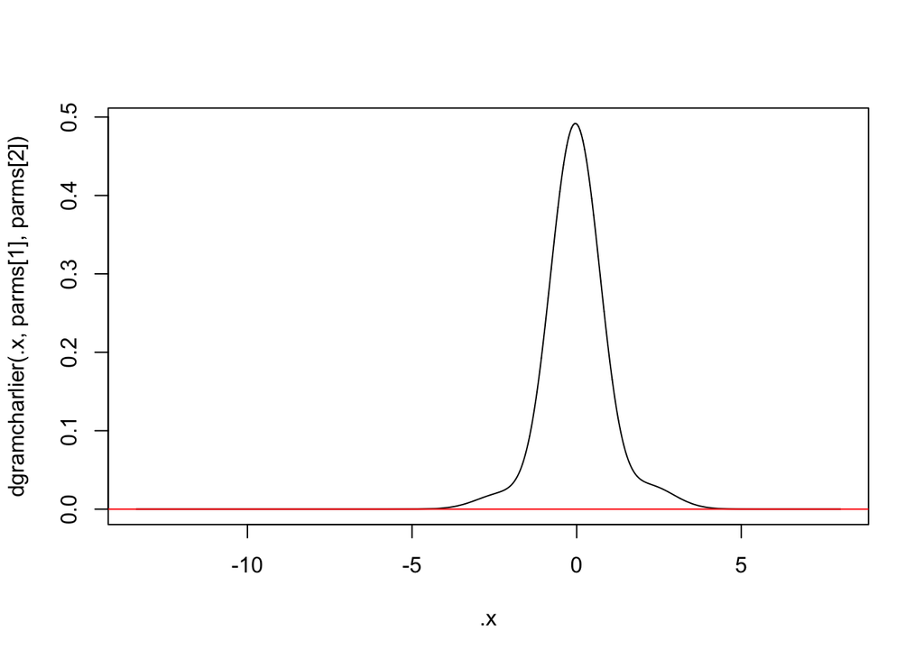

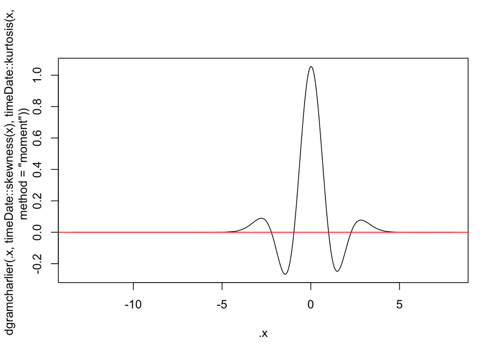

```r
.x <- sort(x)
parms <- uncons_regionD(res$par[1], res$par[2])
plot(.x, dgramcharlier(.x, parms[1], parms[2]), type='l')
abline(h=0, col="red")
plot(.x, dgramcharlier(.x, timeDate::skewness(x), timeDate::kurtosis(x, method='moment')), type='l')
abline(h=0, col="red")
```

## Apêndice

### Fórmulas importantes

Produto interno de polinômios Chebyshev-Hermite:

$$\int^\infty_{-\infty} e^{-x^2/2} He_n(x) He_m(x) dx = \delta_{mn} n! \sqrt{2\pi}$$

## Referências

[1] S. Blinnikov and R. Moessner, Astronomy and Astrophysics Supplement Series **130**, 193 (1998).